# descriptiveScript

eb.navarro

June 15, 2016

# DESCRIPTIVE ANALYSIS

## Introduction

This Markdown Script is intended to show a descriptive analysis of the Titanic’s challenge data. Many functions in it (loadCleanData, plot.hist.density, …) have been included in the git repository (loadData.R).

### Loading the data

First of all, we load the data as it is in the R console. This process has been included in a function () to future ussage.

The object “fullData” includes train and test sets distinguished by the column named “SampleOrigin”.

```r
source("R/loadData.R")
fullData <- loadCleanData()
str(fullData)
```

```
## 'data.frame':    1309 obs. of  13 variables:
##  $ PassengerId : int  1 2 3 4 5 6 7 8 9 10 ...
##  $ Survived    : Factor w/ 2 levels "0","1": 1 2 2 2 1 1 1 1 2 2 ...
##  $ Pclass      : Factor w/ 3 levels "1","2","3": 3 1 3 1 3 3 1 3 3 2 ...
##  $ Name        : chr  "Braund, Mr. Owen Harris" "Cumings, Mrs. John Bradley (Florence Briggs Thayer)" "Heikkinen, Miss. Laina" "Futrelle, Mrs. Jacques Heath (Lily May Peel)" ...
##  $ Sex         : Factor w/ 2 levels "female","male": 2 1 1 1 2 2 2 2 1 1 ...
##  $ Age         : num  22 38 26 35 35 NA 54 2 27 14 ...
##  $ SibSp       : int  1 1 0 1 0 0 0 3 0 1 ...
##  $ Parch       : int  0 0 0 0 0 0 0 1 2 0 ...
##  $ Ticket      : chr  "A/5 21171" "PC 17599" "STON/O2. 3101282" "113803" ...
##  $ Fare        : num  7.25 71.28 7.92 53.1 8.05 ...
##  $ Cabin       : chr  "" "C85" "" "C123" ...
##  $ Embarked    : Factor w/ 4 levels "","C","Q","S": 4 2 4 4 4 3 4 4 4 2 ...
##  $ SampleOrigin: Factor w/ 2 levels "TEST","TRAIN": 2 2 2 2 2 2 2 2 2 2 ...
```

```r
summary(fullData)
```

```
##   PassengerId   Survived   Pclass      Name               Sex
##  Min.   :   1   0   :549   1:323   Length:1309        female:466
##  1st Qu.: 328   1   :342   2:277   Class :character   male  :843
##  Median : 655   NA's:418   3:709   Mode  :character
##  Mean   : 655
##  3rd Qu.: 982
##  Max.   :1309
##
##       Age            SibSp            Parch          Ticket
##  Min.   : 0.17   Min.   :0.0000   Min.   :0.000   Length:1309
##  1st Qu.:21.00   1st Qu.:0.0000   1st Qu.:0.000   Class :character
##  Median :28.00   Median :0.0000   Median :0.000   Mode  :character
##  Mean   :29.88   Mean   :0.4989   Mean   :0.385
##  3rd Qu.:39.00   3rd Qu.:1.0000   3rd Qu.:0.000
##  Max.   :80.00   Max.   :8.0000   Max.   :9.000
##  NA's   :263
##       Fare            Cabin           Embarked SampleOrigin
##  Min.   :  0.000   Length:1309         :  2    TEST :418
##  1st Qu.:  7.896   Class :character   C:270    TRAIN:891
##  Median : 14.454   Mode  :character   Q:123
##  Mean   : 33.295                      S:914
##  3rd Qu.: 31.275
##  Max.   :512.329
##  NA's   :1
```

This shows that there are a total of 1309 observations (TRAIN: 891, TEST: 418) and 12 variables (+ additionally created “SampleOrigin”). The variables are quantitative and qualitative, also some of them has unkonw values in the observations, i.e. “Survived” (resolve them is the finality of the challenge), “Age”, “Fare”, “Embarked”.

### Descriptive plots. Quatitative data

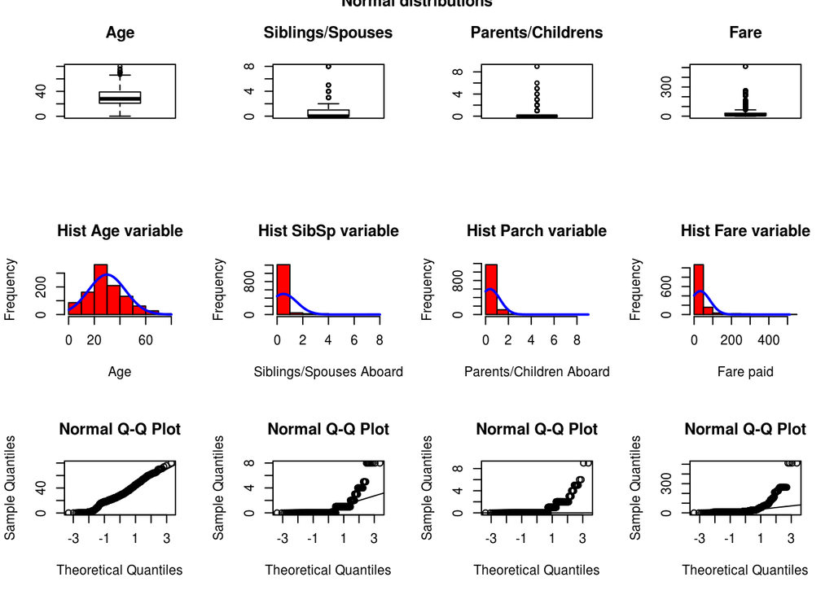

```r
par(mfrow=c(3, 4))
x.age <- fullData[!is.na(fullData$Age),]$Age
x.sibsp <- fullData[!is.na(fullData$SibSp),]$SibSp
x.parch <- fullData[!is.na(fullData$Parch),]$Parch
x.fare <- fullData[!is.na(fullData$Fare),]$Fare

boxplot(x.age, main="Age")
boxplot(x.sibsp, main="Siblings/Spouses")
boxplot(x.parch, main="Parents/Childrens")
boxplot(x.fare, main="Fare")

normal.charts(x.age, "Hist Age variable", "Age", FALSE)
normal.charts(x.sibsp, "Hist SibSp variable", "Siblings/Spouses Aboard", FALSE)
normal.charts(x.parch, "Hist Parch variable", "Parents/Children Aboard", FALSE)
normal.charts(x.fare, "Hist Fare variable", "Fare paid", FALSE)

qqnorm(x.age)
qqline(x.age)
qqnorm(x.sibsp)
qqline(x.sibsp)
qqnorm(x.parch)
qqline(x.parch)
qqnorm(x.fare)
qqline(x.fare)
title("Normal distributions", outer = TRUE)
```

We can observe that all of these variables distributions contain many outliers which may be treated in future sections.

Additionally SibSp and Parch may be considered “count data” which usually follow a Poisson distribution.

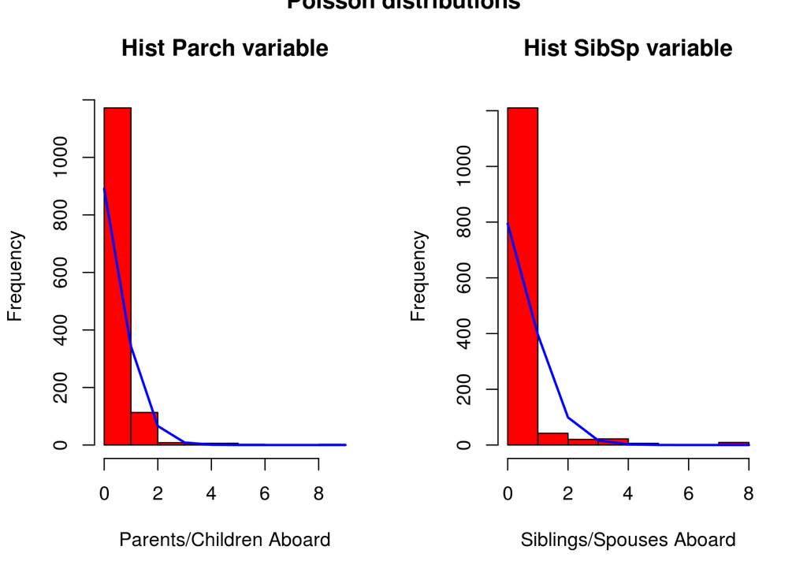

```r
par(mfrow=c(1, 2))
poisson.charts(x.parch, "Hist Parch variable", "Parents/Children Aboard")
poisson.charts(x.sibsp, "Hist SibSp variable", "Siblings/Spouses Aboard")
title("Poisson distributions", outer = TRUE)
```

### Descriptive plots. Qualitative data

Bar and pie plots to visualize the qualitative data. Variables: “Pclass”, “Sex”, “Embarked” and “Survived”.

```r
x.pclass <- fullData[!is.na(fullData$Pclass),]$Pclass
x.sex <- fullData[!is.na(fullData$Sex),]$Sex
x.embarked <- fullData[!is.na(fullData$Embarked),]$Embarked
x.survived <- fullData[!is.na(fullData$Survived),]$Survived

par(mfrow=c(2, 4))
plot(x.pclass, main="Trip classes")
plot(x.sex, main="Sex")
plot(x.embarked, main="Embarked on")
plot(x.survived, main="Survived")
title("Known qualitative data", outer = TRUE)

x.pclass.table <- table(x.pclass)
x.sex.table <- table(x.sex)
x.embarked.table <- table(x.embarked)
x.survived.table <- table(x.survived)

prop.table(x.pclass.table)
```

```
## x.pclass
##         1         2         3
## 0.2467532 0.2116119 0.5416348
```

```r
prop.table(x.sex.table)
```

```
## x.sex
##    female      male
## 0.3559969 0.6440031
```

```r
prop.table(x.embarked.table)
```

```
## x.embarked
##                       C           Q           S
## 0.001527884 0.206264324 0.093964859 0.698242934
```

```r
prop.table(x.survived.table)
```

```
## x.survived
##         0         1
## 0.6161616 0.3838384
```

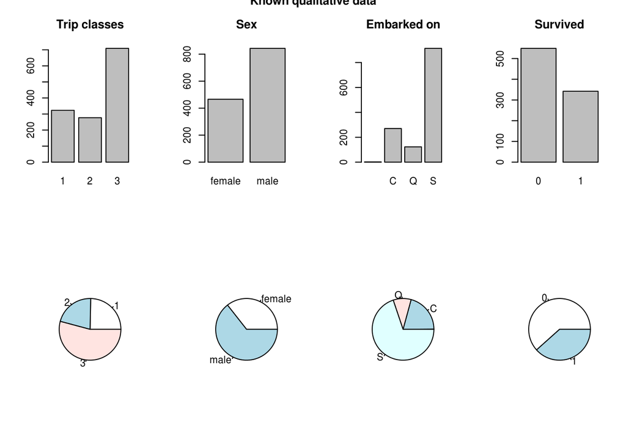

```r
pie(x.pclass.table)
pie(x.sex.table)
pie(x.embarked.table)
pie(x.survived.table)
```

Finally, a contingency table is created to visualize the “Survived” variable against the other factors. A barplot is also created to show the frequency of the diferent factor aggregations.

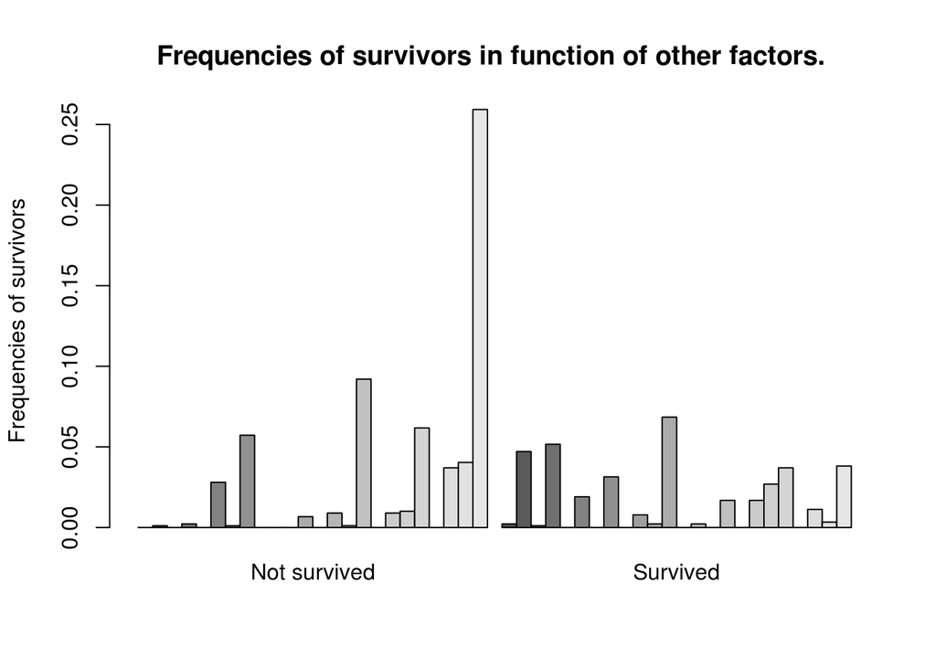

```r
par(mfrow=c(1, 1))
quali.xtabs <- xtabs(~Pclass+Sex+Embarked+Survived, data=fullData)
quali.xtabs.ftable <- ftable(quali.xtabs)
quali.xtabs.proptable <- prop.table(quali.xtabs.ftable)
barplot(prop.table(quali.xtabs.proptable),
        main = "Frequencies of survivors in function of other factors. ",
        ylab ="Frequencies of survivors",
        names.arg = c("Not survived","Survived"),
        beside = TRUE
        )
```

```r
quali.xtabs.ftable
```

```
##                        Survived   0   1
## Pclass Sex    Embarked
## 1      female                     0   2
##               C                   1  42
##               Q                   0   1
##               S                   2  46
##        male                       0   0
##               C                  25  17
##               Q                   1   0
##               S                  51  28
## 2      female                     0   0
##               C                   0   7
##               Q                   0   2
##               S                   6  61
##        male                       0   0
##               C                   8   2
##               Q                   1   0
##               S                  82  15
## 3      female                     0   0
##               C                   8  15
##               Q                   9  24
##               S                  55  33
##        male                       0   0
##               C                  33  10
##               Q                  36   3
##               S                 231  34
```

```r
as.data.frame(quali.xtabs.ftable)
```

```
##    Pclass    Sex Embarked Survived Freq
## 1       1 female                 0    0
## 2       2 female                 0    0
## 3       3 female                 0    0
## 4       1   male                 0    0
## 5       2   male                 0    0
## 6       3   male                 0    0
## 7       1 female        C        0    1
## 8       2 female        C        0    0
## 9       3 female        C        0    8
## 10      1   male        C        0   25
## 11      2   male        C        0    8
## 12      3   male        C        0   33
## 13      1 female        Q        0    0
## 14      2 female        Q        0    0
```

[output cut: 34 more lines]